# Hypothesis testing and $p$-values

DSCI 632: Statistics for Data Science

Peter Ralph

# Hypothesis testing and $p$-values

## A $p$-value is

> the probability of seeing a result at least as surprising as what was observed in the data, if the null hypothesis is true.

Usually, this means

- *a result* - numerical value of a statistic
- *surprising* - big
- *null hypothesis* - the model we use to calculate the $p$-value

which can all be defined to suit the situation.

## What does a small $p$-value mean?

*If* the null hypothesis *were* true, then you’d be really unlikely to see something like what you actually *did*.

So, either the “null hypothesis” is not a good description of reality or something surprising happened.

How useful this is depends on the null hypothesis.

## For instance

```r
(tt <- t.test(
        airbnb$price[airbnb$instant_bookable],
        airbnb$price[!airbnb$instant_bookable]
))
```

```
##
##  Welch Two Sample t-test
##
## data:  airbnb$price[airbnb$instant_bookable] and airbnb$price[!airbnb$instant_bookable]
## t = 3.6482, df = 5039.8, p-value = 0.0002667
## alternative hypothesis: true difference in means is not equal to 0
## 95 percent confidence interval:
##   4.475555 14.872518
## sample estimates:
## mean of x mean of y
##  124.6409  114.9668
```

## Also for instance

```r
t.test(airbnb$price)
```

```
##
##  One Sample t-test
##
## data:  airbnb$price
## t = 91.32, df = 5601, p-value < 2.2e-16
## alternative hypothesis: true mean is not equal to 0
## 95 percent confidence interval:
##  116.9734 122.1058
## sample estimates:
## mean of x
##  119.5396
```

Is *that* $p$-value useful?

## Exercise:

*My hypothesis:* People tend to have longer index fingers on the hand they write with because writing stretches the ligaments.

*(class survey)* How many people have a longer index finger on the hand they write with?

*(class survey)* Everyone flip a coin:

```
ifelse(runif(1) < 0.5, "H", "T")
```

We want to estimate the parameter

$$\begin{equation}
\theta = \P(\text{random person has writing finger longer}) ,
\end{equation}$$

and now we have a *fake dataset with $\theta = 1/2$*.

Let’s get some more data:

```
n <- 37 # class size
sum(ifelse(runif(n) < 1/2, "H", "T") == "H")
```

Now we can estimate the $p$-value for the hypothesis that $\theta = 1/2$.

A faster method:

```
replicate(1000, sum(rbinom(n, 1, 1/2) > 0))
```

or, equivalently,

```
rbinom(1000, n, 1/2)
```

## (in class)

## So, where do $p$-values come from?

Either math:

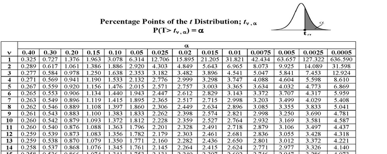

table of p-values from a t distribution

Or, computers. (maybe math, maybe simulation, maybe both)

So, where did *this* $p$-value come from?

```r
(tt <- t.test(
        airbnb$price[airbnb$instant_bookable],
        airbnb$price[!airbnb$instant_bookable]
))
```

```
##
##  Welch Two Sample t-test
##
## data:  airbnb$price[airbnb$instant_bookable] and airbnb$price[!airbnb$instant_bookable]
## t = 3.6482, df = 5039.8, p-value = 0.0002667
## alternative hypothesis: true difference in means is not equal to 0
## 95 percent confidence interval:
##   4.475555 14.872518
## sample estimates:
## mean of x mean of y
##  124.6409  114.9668
```

The $t$ distribution! (see separate slides)